# Risk Factor Analysis

## Outcome Variable

**Outcome Variable:** pers_wast

## Predictor Variables

**Intervention Variable:** parity

**Adjustment Set:**

- arm
- W_mage
- meducyrs
- feducyrs
- hhwealth_quart
- W_mhtcm
- vagbrth
- impsan
- delta_W_mage
- delta_meducyrs
- delta_feducyrs
- delta_hhwealth_quart
- delta_W_mhtcm
- delta_vagbrth
- delta_impsan

## Stratifying Variables

The analysis was stratified on these variable(s):

- agecat
- studyid
- country

## Data Summary

| agecat | studyid | country | parity | pers_wast | n_cell | n |
| --- | --- | --- | --- | --- | --- | --- |
| 0-24 months | ki1000304b-SAS-CompFeed | INDIA | 1 | 0 | 378 | 1366 |
| 0-24 months | ki1000304b-SAS-CompFeed | INDIA | 1 | 1 | 30 | 1366 |
| 0-24 months | ki1000304b-SAS-CompFeed | INDIA | 2 | 0 | 291 | 1366 |
| 0-24 months | ki1000304b-SAS-CompFeed | INDIA | 2 | 1 | 27 | 1366 |
| 0-24 months | ki1000304b-SAS-CompFeed | INDIA | 3+ | 0 | 583 | 1366 |
| 0-24 months | ki1000304b-SAS-CompFeed | INDIA | 3+ | 1 | 57 | 1366 |
| 0-24 months | ki1000304b-SAS-FoodSuppl | INDIA | 1 | 0 | 62 | 373 |
| 0-24 months | ki1000304b-SAS-FoodSuppl | INDIA | 1 | 1 | 7 | 373 |
| 0-24 months | ki1000304b-SAS-FoodSuppl | INDIA | 2 | 0 | 76 | 373 |
| 0-24 months | ki1000304b-SAS-FoodSuppl | INDIA | 2 | 1 | 11 | 373 |
| 0-24 months | ki1000304b-SAS-FoodSuppl | INDIA | 3+ | 0 | 171 | 373 |
| 0-24 months | ki1000304b-SAS-FoodSuppl | INDIA | 3+ | 1 | 46 | 373 |
| 0-24 months | ki1017093b-PROVIDE | BANGLADESH | 1 | 0 | 237 | 640 |
| 0-24 months | ki1017093b-PROVIDE | BANGLADESH | 1 | 1 | 4 | 640 |
| 0-24 months | ki1017093b-PROVIDE | BANGLADESH | 2 | 0 | 223 | 640 |
| 0-24 months | ki1017093b-PROVIDE | BANGLADESH | 2 | 1 | 4 | 640 |
| 0-24 months | ki1017093b-PROVIDE | BANGLADESH | 3+ | 0 | 165 | 640 |
| 0-24 months | ki1017093b-PROVIDE | BANGLADESH | 3+ | 1 | 7 | 640 |
| 0-24 months | ki1066203-TanzaniaChild2 | TANZANIA, UNITED REPUBLIC OF | 1 | 0 | 710 | 2132 |
| 0-24 months | ki1066203-TanzaniaChild2 | TANZANIA, UNITED REPUBLIC OF | 1 | 1 | 18 | 2132 |
| 0-24 months | ki1066203-TanzaniaChild2 | TANZANIA, UNITED REPUBLIC OF | 2 | 0 | 683 | 2132 |
| 0-24 months | ki1066203-TanzaniaChild2 | TANZANIA, UNITED REPUBLIC OF | 2 | 1 | 20 | 2132 |
| 0-24 months | ki1066203-TanzaniaChild2 | TANZANIA, UNITED REPUBLIC OF | 3+ | 0 | 682 | 2132 |
| 0-24 months | ki1066203-TanzaniaChild2 | TANZANIA, UNITED REPUBLIC OF | 3+ | 1 | 19 | 2132 |
| 0-24 months | ki1101329-Keneba | GAMBIA | 1 | 0 | 220 | 1850 |
| 0-24 months | ki1101329-Keneba | GAMBIA | 1 | 1 | 9 | 1850 |
| 0-24 months | ki1101329-Keneba | GAMBIA | 2 | 0 | 190 | 1850 |
| 0-24 months | ki1101329-Keneba | GAMBIA | 2 | 1 | 9 | 1850 |
| 0-24 months | ki1101329-Keneba | GAMBIA | 3+ | 0 | 1350 | 1850 |
| 0-24 months | ki1101329-Keneba | GAMBIA | 3+ | 1 | 72 | 1850 |

[output cut: 144 more lines]

The following strata were considered:

- agecat: 0-24 months, studyid: ki1000304b-SAS-CompFeed, country: INDIA
- agecat: 0-24 months, studyid: ki1000304b-SAS-FoodSuppl, country: INDIA
- agecat: 0-24 months, studyid: ki1017093b-PROVIDE, country: BANGLADESH
- agecat: 0-24 months, studyid: ki1066203-TanzaniaChild2, country: TANZANIA, UNITED REPUBLIC OF
- agecat: 0-24 months, studyid: ki1101329-Keneba, country: GAMBIA
- agecat: 0-24 months, studyid: ki1113344-GMS-Nepal, country: NEPAL
- agecat: 0-24 months, studyid: ki1126311-ZVITAMBO, country: ZIMBABWE
- agecat: 0-24 months, studyid: ki1135781-COHORTS, country: GUATEMALA
- agecat: 0-24 months, studyid: ki1135781-COHORTS, country: INDIA
- agecat: 0-24 months, studyid: ki1135781-COHORTS, country: PHILIPPINES
- agecat: 0-24 months, studyid: kiGH5241-JiVitA-3, country: BANGLADESH
- agecat: 0-6 months, studyid: ki1017093b-PROVIDE, country: BANGLADESH
- agecat: 0-6 months, studyid: ki1066203-TanzaniaChild2, country: TANZANIA, UNITED REPUBLIC OF
- agecat: 0-6 months, studyid: ki1101329-Keneba, country: GAMBIA
- agecat: 0-6 months, studyid: ki1113344-GMS-Nepal, country: NEPAL
- agecat: 0-6 months, studyid: ki1126311-ZVITAMBO, country: ZIMBABWE
- agecat: 0-6 months, studyid: ki1135781-COHORTS, country: PHILIPPINES
- agecat: 0-6 months, studyid: kiGH5241-JiVitA-3, country: BANGLADESH
- agecat: 6-24 months, studyid: ki1000304b-SAS-CompFeed, country: INDIA
- agecat: 6-24 months, studyid: ki1000304b-SAS-FoodSuppl, country: INDIA
- agecat: 6-24 months, studyid: ki1017093b-PROVIDE, country: BANGLADESH
- agecat: 6-24 months, studyid: ki1066203-TanzaniaChild2, country: TANZANIA, UNITED REPUBLIC OF
- agecat: 6-24 months, studyid: ki1101329-Keneba, country: GAMBIA
- agecat: 6-24 months, studyid: ki1113344-GMS-Nepal, country: NEPAL
- agecat: 6-24 months, studyid: ki1126311-ZVITAMBO, country: ZIMBABWE
- agecat: 6-24 months, studyid: ki1135781-COHORTS, country: GUATEMALA
- agecat: 6-24 months, studyid: ki1135781-COHORTS, country: INDIA
- agecat: 6-24 months, studyid: ki1135781-COHORTS, country: PHILIPPINES
- agecat: 6-24 months, studyid: kiGH5241-JiVitA-3, country: BANGLADESH

### Dropped Strata

Some strata were dropped due to rare outcomes:

- agecat: 0-24 months, studyid: ki1017093b-PROVIDE, country: BANGLADESH
- agecat: 0-24 months, studyid: ki1135781-COHORTS, country: GUATEMALA
- agecat: 0-6 months, studyid: ki1017093b-PROVIDE, country: BANGLADESH
- agecat: 0-6 months, studyid: ki1101329-Keneba, country: GAMBIA
- agecat: 0-6 months, studyid: ki1126311-ZVITAMBO, country: ZIMBABWE
- agecat: 0-6 months, studyid: kiGH5241-JiVitA-3, country: BANGLADESH
- agecat: 6-24 months, studyid: ki1017093b-PROVIDE, country: BANGLADESH
- agecat: 6-24 months, studyid: ki1135781-COHORTS, country: GUATEMALA

## Methods Detail

We’re interested in the causal parameters $E[Y_a]$ for all values of $a \in \mathcal{A}$. These parameters represent the mean outcome if, possibly contrary to fact, we intervened to set all units to have $A=a$. Under the randomization and positivity assumptions, these are identified by the statistical parameters $\psi_a=E_W[E_{Y|A,W}(Y|A=a,W)]$. In addition, we’re interested in the mean of $Y$, $E[Y]$ under no intervention (the observed mean). We will estimate these parameters by using SuperLearner to fit the relevant likelihood factors – $E_{Y|A,W}(Y|A=a,W)$ and $p(A=a|W)$, and then updating our likelihood fit using a joint TMLE.

For unadjusted analyses ($W=\{\}$), initial likelihoods were estimated using Lrnr_glm to estimate the simple $E(Y|A)$ and Lrnr_mean to estimate $p(A)$. For adjusted analyses, a small library containing Lrnr_glmnet, Lrnr_xgboost, and Lrnr_mean was used.

Having estimated these parameters, we will then use the delta method to estimate relative risks and attributable risks relative to a prespecified baseline level of $A$.

# Results Detail

## Results Plots

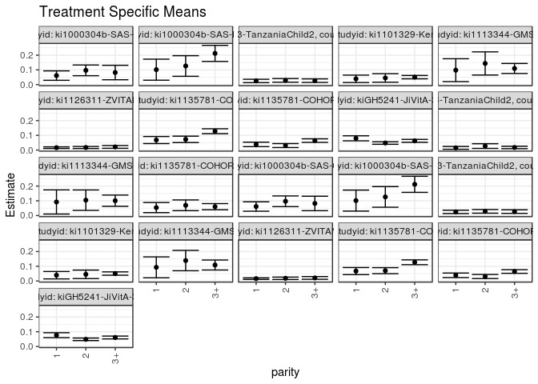

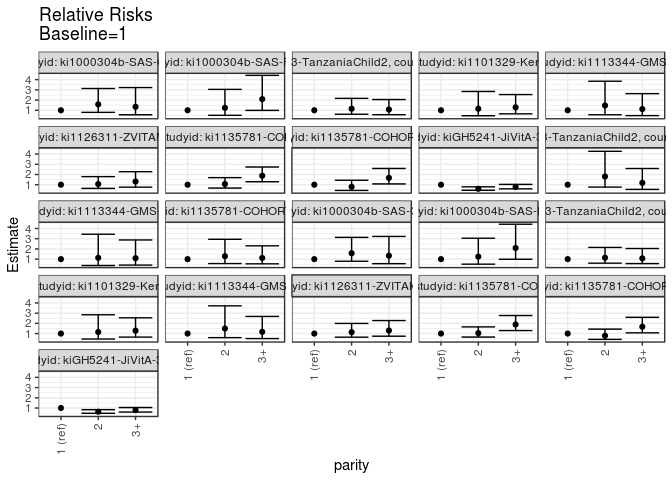

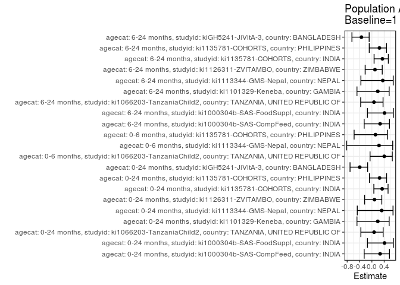

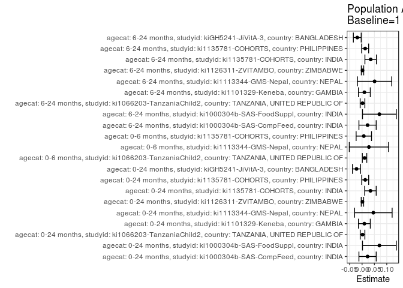

## Results Table

### Parameter: TSM

| agecat | studyid | country | intervention_level | baseline_level | estimate | ci_lower | ci_upper |
| --- | --- | --- | --- | --- | --- | --- | --- |
| 0-24 months | ki1000304b-SAS-CompFeed | INDIA | 1 | NA | 0.0612154 | 0.0292447 | 0.0931861 |
| 0-24 months | ki1000304b-SAS-CompFeed | INDIA | 2 | NA | 0.0967276 | 0.0603010 | 0.1331541 |
| 0-24 months | ki1000304b-SAS-CompFeed | INDIA | 3+ | NA | 0.0820545 | 0.0328692 | 0.1312398 |
| 0-24 months | ki1000304b-SAS-FoodSuppl | INDIA | 1 | NA | 0.1014493 | 0.0301143 | 0.1727842 |
| 0-24 months | ki1000304b-SAS-FoodSuppl | INDIA | 2 | NA | 0.1264368 | 0.0565081 | 0.1963655 |
| 0-24 months | ki1000304b-SAS-FoodSuppl | INDIA | 3+ | NA | 0.2119816 | 0.1575290 | 0.2664341 |
| 0-24 months | ki1066203-TanzaniaChild2 | TANZANIA, UNITED REPUBLIC OF | 1 | NA | 0.0248113 | 0.0134293 | 0.0361934 |
| 0-24 months | ki1066203-TanzaniaChild2 | TANZANIA, UNITED REPUBLIC OF | 2 | NA | 0.0285560 | 0.0161699 | 0.0409422 |
| 0-24 months | ki1066203-TanzaniaChild2 | TANZANIA, UNITED REPUBLIC OF | 3+ | NA | 0.0267835 | 0.0147270 | 0.0388400 |
| 0-24 months | ki1101329-Keneba | GAMBIA | 1 | NA | 0.0393013 | 0.0141277 | 0.0644749 |
| 0-24 months | ki1101329-Keneba | GAMBIA | 2 | NA | 0.0452261 | 0.0163470 | 0.0741053 |
| 0-24 months | ki1101329-Keneba | GAMBIA | 3+ | NA | 0.0506329 | 0.0392344 | 0.0620315 |
| 0-24 months | ki1113344-GMS-Nepal | NEPAL | 1 | NA | 0.0978766 | 0.0201593 | 0.1755938 |
| 0-24 months | ki1113344-GMS-Nepal | NEPAL | 2 | NA | 0.1436234 | 0.0649565 | 0.2222903 |
| 0-24 months | ki1113344-GMS-Nepal | NEPAL | 3+ | NA | 0.1095801 | 0.0755981 | 0.1435622 |
| 0-24 months | ki1126311-ZVITAMBO | ZIMBABWE | 1 | NA | 0.0163820 | 0.0109102 | 0.0218539 |
| 0-24 months | ki1126311-ZVITAMBO | ZIMBABWE | 2 | NA | 0.0175136 | 0.0106488 | 0.0243783 |
| 0-24 months | ki1126311-ZVITAMBO | ZIMBABWE | 3+ | NA | 0.0215218 | 0.0121368 | 0.0309068 |
| 0-24 months | ki1135781-COHORTS | INDIA | 1 | NA | 0.0681416 | 0.0441193 | 0.0921640 |
| 0-24 months | ki1135781-COHORTS | INDIA | 2 | NA | 0.0727049 | 0.0509686 | 0.0944413 |
| 0-24 months | ki1135781-COHORTS | INDIA | 3+ | NA | 0.1280039 | 0.1114369 | 0.1445709 |
| 0-24 months | ki1135781-COHORTS | PHILIPPINES | 1 | NA | 0.0384867 | 0.0232202 | 0.0537533 |
| 0-24 months | ki1135781-COHORTS | PHILIPPINES | 2 | NA | 0.0306140 | 0.0171197 | 0.0441083 |
| 0-24 months | ki1135781-COHORTS | PHILIPPINES | 3+ | NA | 0.0642530 | 0.0521267 | 0.0763794 |
| 0-24 months | kiGH5241-JiVitA-3 | BANGLADESH | 1 | NA | 0.0797643 | 0.0627341 | 0.0967945 |
| 0-24 months | kiGH5241-JiVitA-3 | BANGLADESH | 2 | NA | 0.0479968 | 0.0393673 | 0.0566262 |
| 0-24 months | kiGH5241-JiVitA-3 | BANGLADESH | 3+ | NA | 0.0626456 | 0.0527400 | 0.0725513 |
| 0-6 months | ki1066203-TanzaniaChild2 | TANZANIA, UNITED REPUBLIC OF | 1 | NA | 0.0150506 | 0.0055290 | 0.0245721 |
| 0-6 months | ki1066203-TanzaniaChild2 | TANZANIA, UNITED REPUBLIC OF | 2 | NA | 0.0271965 | 0.0113759 | 0.0430170 |
| 0-6 months | ki1066203-TanzaniaChild2 | TANZANIA, UNITED REPUBLIC OF | 3+ | NA | 0.0177999 | 0.0096319 | 0.0259679 |
| 0-6 months | ki1113344-GMS-Nepal | NEPAL | 1 | NA | 0.0921015 | 0.0101954 | 0.1740076 |
| 0-6 months | ki1113344-GMS-Nepal | NEPAL | 2 | NA | 0.1043803 | 0.0350719 | 0.1736887 |
| 0-6 months | ki1113344-GMS-Nepal | NEPAL | 3+ | NA | 0.1008320 | 0.0627740 | 0.1388899 |
| 0-6 months | ki1135781-COHORTS | PHILIPPINES | 1 | NA | 0.0538922 | 0.0196251 | 0.0881594 |
| 0-6 months | ki1135781-COHORTS | PHILIPPINES | 2 | NA | 0.0695187 | 0.0330444 | 0.1059930 |
| 0-6 months | ki1135781-COHORTS | PHILIPPINES | 3+ | NA | 0.0601202 | 0.0392514 | 0.0809891 |
| 6-24 months | ki1000304b-SAS-CompFeed | INDIA | 1 | NA | 0.0612154 | 0.0292447 | 0.0931861 |
| 6-24 months | ki1000304b-SAS-CompFeed | INDIA | 2 | NA | 0.0967276 | 0.0603010 | 0.1331541 |
| 6-24 months | ki1000304b-SAS-CompFeed | INDIA | 3+ | NA | 0.0820545 | 0.0328692 | 0.1312398 |
| 6-24 months | ki1000304b-SAS-FoodSuppl | INDIA | 1 | NA | 0.1014493 | 0.0301143 | 0.1727842 |
| 6-24 months | ki1000304b-SAS-FoodSuppl | INDIA | 2 | NA | 0.1264368 | 0.0565081 | 0.1963655 |
| 6-24 months | ki1000304b-SAS-FoodSuppl | INDIA | 3+ | NA | 0.2119816 | 0.1575290 | 0.2664341 |
| 6-24 months | ki1066203-TanzaniaChild2 | TANZANIA, UNITED REPUBLIC OF | 1 | NA | 0.0249222 | 0.0134961 | 0.0363484 |
| 6-24 months | ki1066203-TanzaniaChild2 | TANZANIA, UNITED REPUBLIC OF | 2 | NA | 0.0283648 | 0.0159690 | 0.0407605 |
| 6-24 months | ki1066203-TanzaniaChild2 | TANZANIA, UNITED REPUBLIC OF | 3+ | NA | 0.0267301 | 0.0146588 | 0.0388015 |
| 6-24 months | ki1101329-Keneba | GAMBIA | 1 | NA | 0.0393013 | 0.0141277 | 0.0644749 |
| 6-24 months | ki1101329-Keneba | GAMBIA | 2 | NA | 0.0452261 | 0.0163470 | 0.0741053 |
| 6-24 months | ki1101329-Keneba | GAMBIA | 3+ | NA | 0.0506329 | 0.0392344 | 0.0620315 |
| 6-24 months | ki1113344-GMS-Nepal | NEPAL | 1 | NA | 0.0928696 | 0.0218827 | 0.1638564 |
| 6-24 months | ki1113344-GMS-Nepal | NEPAL | 2 | NA | 0.1387380 | 0.0695646 | 0.2079115 |
| 6-24 months | ki1113344-GMS-Nepal | NEPAL | 3+ | NA | 0.1086190 | 0.0747492 | 0.1424887 |
| 6-24 months | ki1126311-ZVITAMBO | ZIMBABWE | 1 | NA | 0.0160982 | 0.0106647 | 0.0215317 |
| 6-24 months | ki1126311-ZVITAMBO | ZIMBABWE | 2 | NA | 0.0183163 | 0.0101365 | 0.0264960 |
| 6-24 months | ki1126311-ZVITAMBO | ZIMBABWE | 3+ | NA | 0.0209037 | 0.0115820 | 0.0302255 |
| 6-24 months | ki1135781-COHORTS | INDIA | 1 | NA | 0.0672299 | 0.0431972 | 0.0912626 |
| 6-24 months | ki1135781-COHORTS | INDIA | 2 | NA | 0.0701773 | 0.0497741 | 0.0905805 |
| 6-24 months | ki1135781-COHORTS | INDIA | 3+ | NA | 0.1272015 | 0.1108370 | 0.1435661 |
| 6-24 months | ki1135781-COHORTS | PHILIPPINES | 1 | NA | 0.0386937 | 0.0233270 | 0.0540604 |
| 6-24 months | ki1135781-COHORTS | PHILIPPINES | 2 | NA | 0.0305139 | 0.0168485 | 0.0441793 |
| 6-24 months | ki1135781-COHORTS | PHILIPPINES | 3+ | NA | 0.0645193 | 0.0522626 | 0.0767761 |
| 6-24 months | kiGH5241-JiVitA-3 | BANGLADESH | 1 | NA | 0.0765916 | 0.0599404 | 0.0932428 |
| 6-24 months | kiGH5241-JiVitA-3 | BANGLADESH | 2 | NA | 0.0486053 | 0.0398987 | 0.0573118 |
| 6-24 months | kiGH5241-JiVitA-3 | BANGLADESH | 3+ | NA | 0.0609654 | 0.0514391 | 0.0704917 |

### Parameter: E(Y)

| agecat | studyid | country | intervention_level | baseline_level | estimate | ci_lower | ci_upper |
| --- | --- | --- | --- | --- | --- | --- | --- |
| 0-24 months | ki1000304b-SAS-CompFeed | INDIA | NA | NA | 0.0834553 | 0.0601989 | 0.1067118 |
| 0-24 months | ki1000304b-SAS-FoodSuppl | INDIA | NA | NA | 0.1715818 | 0.1332696 | 0.2098940 |
| 0-24 months | ki1066203-TanzaniaChild2 | TANZANIA, UNITED REPUBLIC OF | NA | NA | 0.0267355 | 0.0198866 | 0.0335843 |
| 0-24 months | ki1101329-Keneba | GAMBIA | NA | NA | 0.0486486 | 0.0388428 | 0.0584545 |
| 0-24 months | ki1113344-GMS-Nepal | NEPAL | NA | NA | 0.1435811 | 0.1153098 | 0.1718524 |
| 0-24 months | ki1126311-ZVITAMBO | ZIMBABWE | NA | NA | 0.0178954 | 0.0152055 | 0.0205853 |
| 0-24 months | ki1135781-COHORTS | INDIA | NA | NA | 0.1020862 | 0.0921879 | 0.1119845 |
| 0-24 months | ki1135781-COHORTS | PHILIPPINES | NA | NA | 0.0512273 | 0.0430760 | 0.0593786 |
| 0-24 months | kiGH5241-JiVitA-3 | BANGLADESH | NA | NA | 0.0572358 | 0.0531429 | 0.0613287 |
| 0-6 months | ki1066203-TanzaniaChild2 | TANZANIA, UNITED REPUBLIC OF | NA | NA | 0.0251232 | 0.0183136 | 0.0319327 |
| 0-6 months | ki1113344-GMS-Nepal | NEPAL | NA | NA | 0.1199262 | 0.0925504 | 0.1473020 |
| 0-6 months | ki1135781-COHORTS | PHILIPPINES | NA | NA | 0.0609613 | 0.0448957 | 0.0770269 |
| 6-24 months | ki1000304b-SAS-CompFeed | INDIA | NA | NA | 0.0834553 | 0.0601989 | 0.1067118 |
| 6-24 months | ki1000304b-SAS-FoodSuppl | INDIA | NA | NA | 0.1715818 | 0.1332696 | 0.2098940 |
| 6-24 months | ki1066203-TanzaniaChild2 | TANZANIA, UNITED REPUBLIC OF | NA | NA | 0.0267355 | 0.0198866 | 0.0335843 |
| 6-24 months | ki1101329-Keneba | GAMBIA | NA | NA | 0.0486486 | 0.0388428 | 0.0584545 |
| 6-24 months | ki1113344-GMS-Nepal | NEPAL | NA | NA | 0.1435811 | 0.1153098 | 0.1718524 |
| 6-24 months | ki1126311-ZVITAMBO | ZIMBABWE | NA | NA | 0.0178954 | 0.0152055 | 0.0205853 |
| 6-24 months | ki1135781-COHORTS | INDIA | NA | NA | 0.1020862 | 0.0921879 | 0.1119845 |
| 6-24 months | ki1135781-COHORTS | PHILIPPINES | NA | NA | 0.0512273 | 0.0430760 | 0.0593786 |
| 6-24 months | kiGH5241-JiVitA-3 | BANGLADESH | NA | NA | 0.0572358 | 0.0531429 | 0.0613287 |

### Parameter: RR

| agecat | studyid | country | intervention_level | baseline_level | estimate | ci_lower | ci_upper |
| --- | --- | --- | --- | --- | --- | --- | --- |
| 0-24 months | ki1000304b-SAS-CompFeed | INDIA | 1 | 1 | 1.0000000 | 1.0000000 | 1.0000000 |
| 0-24 months | ki1000304b-SAS-CompFeed | INDIA | 2 | 1 | 1.5801175 | 0.7973545 | 3.1313192 |
| 0-24 months | ki1000304b-SAS-CompFeed | INDIA | 3+ | 1 | 1.3404226 | 0.5573966 | 3.2234364 |
| 0-24 months | ki1000304b-SAS-FoodSuppl | INDIA | 1 | 1 | 1.0000000 | 1.0000000 | 1.0000000 |
| 0-24 months | ki1000304b-SAS-FoodSuppl | INDIA | 2 | 1 | 1.2463054 | 0.5094502 | 3.0489281 |
| 0-24 months | ki1000304b-SAS-FoodSuppl | INDIA | 3+ | 1 | 2.0895326 | 0.9883986 | 4.4173943 |
| 0-24 months | ki1066203-TanzaniaChild2 | TANZANIA, UNITED REPUBLIC OF | 1 | 1 | 1.0000000 | 1.0000000 | 1.0000000 |
| 0-24 months | ki1066203-TanzaniaChild2 | TANZANIA, UNITED REPUBLIC OF | 2 | 1 | 1.1509275 | 0.6120341 | 2.1643143 |
| 0-24 months | ki1066203-TanzaniaChild2 | TANZANIA, UNITED REPUBLIC OF | 3+ | 1 | 1.0794867 | 0.5675966 | 2.0530276 |
| 0-24 months | ki1101329-Keneba | GAMBIA | 1 | 1 | 1.0000000 | 1.0000000 | 1.0000000 |
| 0-24 months | ki1101329-Keneba | GAMBIA | 2 | 1 | 1.1507536 | 0.4657865 | 2.8430063 |
| 0-24 months | ki1101329-Keneba | GAMBIA | 3+ | 1 | 1.2883261 | 0.6533823 | 2.5402955 |
| 0-24 months | ki1113344-GMS-Nepal | NEPAL | 1 | 1 | 1.0000000 | 1.0000000 | 1.0000000 |
| 0-24 months | ki1113344-GMS-Nepal | NEPAL | 2 | 1 | 1.4673930 | 0.5598679 | 3.8459827 |
| 0-24 months | ki1113344-GMS-Nepal | NEPAL | 3+ | 1 | 1.1195750 | 0.4762833 | 2.6317280 |
| 0-24 months | ki1126311-ZVITAMBO | ZIMBABWE | 1 | 1 | 1.0000000 | 1.0000000 | 1.0000000 |
| 0-24 months | ki1126311-ZVITAMBO | ZIMBABWE | 2 | 1 | 1.0690733 | 0.6387886 | 1.7891955 |
| 0-24 months | ki1126311-ZVITAMBO | ZIMBABWE | 3+ | 1 | 1.3137429 | 0.7584902 | 2.2754684 |
| 0-24 months | ki1135781-COHORTS | INDIA | 1 | 1 | 1.0000000 | 1.0000000 | 1.0000000 |
| 0-24 months | ki1135781-COHORTS | INDIA | 2 | 1 | 1.0669675 | 0.6720510 | 1.6939483 |
| 0-24 months | ki1135781-COHORTS | INDIA | 3+ | 1 | 1.8784974 | 1.2904628 | 2.7344861 |
| 0-24 months | ki1135781-COHORTS | PHILIPPINES | 1 | 1 | 1.0000000 | 1.0000000 | 1.0000000 |
| 0-24 months | ki1135781-COHORTS | PHILIPPINES | 2 | 1 | 0.7954426 | 0.4396436 | 1.4391859 |
| 0-24 months | ki1135781-COHORTS | PHILIPPINES | 3+ | 1 | 1.6694847 | 1.0758879 | 2.5905851 |
| 0-24 months | kiGH5241-JiVitA-3 | BANGLADESH | 1 | 1 | 1.0000000 | 1.0000000 | 1.0000000 |
| 0-24 months | kiGH5241-JiVitA-3 | BANGLADESH | 2 | 1 | 0.6017324 | 0.4567463 | 0.7927418 |
| 0-24 months | kiGH5241-JiVitA-3 | BANGLADESH | 3+ | 1 | 0.7853846 | 0.5983372 | 1.0309053 |
| 0-6 months | ki1066203-TanzaniaChild2 | TANZANIA, UNITED REPUBLIC OF | 1 | 1 | 1.0000000 | 1.0000000 | 1.0000000 |
| 0-6 months | ki1066203-TanzaniaChild2 | TANZANIA, UNITED REPUBLIC OF | 2 | 1 | 1.8070063 | 0.7647412 | 4.2697735 |
| 0-6 months | ki1066203-TanzaniaChild2 | TANZANIA, UNITED REPUBLIC OF | 3+ | 1 | 1.1826719 | 0.5406364 | 2.5871597 |
| 0-6 months | ki1113344-GMS-Nepal | NEPAL | 1 | 1 | 1.0000000 | 1.0000000 | 1.0000000 |
| 0-6 months | ki1113344-GMS-Nepal | NEPAL | 2 | 1 | 1.1333181 | 0.3734652 | 3.4391689 |
| 0-6 months | ki1113344-GMS-Nepal | NEPAL | 3+ | 1 | 1.0947921 | 0.4165165 | 2.8776046 |
| 0-6 months | ki1135781-COHORTS | PHILIPPINES | 1 | 1 | 1.0000000 | 1.0000000 | 1.0000000 |
| 0-6 months | ki1135781-COHORTS | PHILIPPINES | 2 | 1 | 1.2899584 | 0.5656642 | 2.9416615 |
| 0-6 months | ki1135781-COHORTS | PHILIPPINES | 3+ | 1 | 1.1155645 | 0.5406060 | 2.3020166 |
| 6-24 months | ki1000304b-SAS-CompFeed | INDIA | 1 | 1 | 1.0000000 | 1.0000000 | 1.0000000 |
| 6-24 months | ki1000304b-SAS-CompFeed | INDIA | 2 | 1 | 1.5801175 | 0.7973545 | 3.1313192 |
| 6-24 months | ki1000304b-SAS-CompFeed | INDIA | 3+ | 1 | 1.3404226 | 0.5573966 | 3.2234364 |
| 6-24 months | ki1000304b-SAS-FoodSuppl | INDIA | 1 | 1 | 1.0000000 | 1.0000000 | 1.0000000 |
| 6-24 months | ki1000304b-SAS-FoodSuppl | INDIA | 2 | 1 | 1.2463054 | 0.5094502 | 3.0489281 |
| 6-24 months | ki1000304b-SAS-FoodSuppl | INDIA | 3+ | 1 | 2.0895326 | 0.9883986 | 4.4173943 |
| 6-24 months | ki1066203-TanzaniaChild2 | TANZANIA, UNITED REPUBLIC OF | 1 | 1 | 1.0000000 | 1.0000000 | 1.0000000 |
| 6-24 months | ki1066203-TanzaniaChild2 | TANZANIA, UNITED REPUBLIC OF | 2 | 1 | 1.1381306 | 0.6040112 | 2.1445649 |
| 6-24 months | ki1066203-TanzaniaChild2 | TANZANIA, UNITED REPUBLIC OF | 3+ | 1 | 1.0725416 | 0.5634570 | 2.0415854 |
| 6-24 months | ki1101329-Keneba | GAMBIA | 1 | 1 | 1.0000000 | 1.0000000 | 1.0000000 |
| 6-24 months | ki1101329-Keneba | GAMBIA | 2 | 1 | 1.1507536 | 0.4657865 | 2.8430063 |
| 6-24 months | ki1101329-Keneba | GAMBIA | 3+ | 1 | 1.2883261 | 0.6533823 | 2.5402955 |
| 6-24 months | ki1113344-GMS-Nepal | NEPAL | 1 | 1 | 1.0000000 | 1.0000000 | 1.0000000 |
| 6-24 months | ki1113344-GMS-Nepal | NEPAL | 2 | 1 | 1.4939021 | 0.6008273 | 3.7144509 |
| 6-24 months | ki1113344-GMS-Nepal | NEPAL | 3+ | 1 | 1.1695863 | 0.5110018 | 2.6769616 |
| 6-24 months | ki1126311-ZVITAMBO | ZIMBABWE | 1 | 1 | 1.0000000 | 1.0000000 | 1.0000000 |
| 6-24 months | ki1126311-ZVITAMBO | ZIMBABWE | 2 | 1 | 1.1377835 | 0.6500470 | 1.9914732 |
| 6-24 months | ki1126311-ZVITAMBO | ZIMBABWE | 3+ | 1 | 1.2985143 | 0.7422423 | 2.2716831 |
| 6-24 months | ki1135781-COHORTS | INDIA | 1 | 1 | 1.0000000 | 1.0000000 | 1.0000000 |
| 6-24 months | ki1135781-COHORTS | INDIA | 2 | 1 | 1.0438409 | 0.6585170 | 1.6546328 |
| 6-24 months | ki1135781-COHORTS | INDIA | 3+ | 1 | 1.8920388 | 1.2941454 | 2.7661580 |
| 6-24 months | ki1135781-COHORTS | PHILIPPINES | 1 | 1 | 1.0000000 | 1.0000000 | 1.0000000 |
| 6-24 months | ki1135781-COHORTS | PHILIPPINES | 2 | 1 | 0.7885997 | 0.4334478 | 1.4347505 |
| 6-24 months | ki1135781-COHORTS | PHILIPPINES | 3+ | 1 | 1.6674361 | 1.0736948 | 2.5895097 |
| 6-24 months | kiGH5241-JiVitA-3 | BANGLADESH | 1 | 1 | 1.0000000 | 1.0000000 | 1.0000000 |
| 6-24 months | kiGH5241-JiVitA-3 | BANGLADESH | 2 | 1 | 0.6346032 | 0.4808180 | 0.8375753 |
| 6-24 months | kiGH5241-JiVitA-3 | BANGLADESH | 3+ | 1 | 0.7959799 | 0.6054810 | 1.0464143 |

### Parameter: PAR

| agecat | studyid | country | intervention_level | baseline_level | estimate | ci_lower | ci_upper |
| --- | --- | --- | --- | --- | --- | --- | --- |
| 0-24 months | ki1000304b-SAS-CompFeed | INDIA | 1 | NA | 0.0222399 | -0.0127241 | 0.0572040 |
| 0-24 months | ki1000304b-SAS-FoodSuppl | INDIA | 1 | NA | 0.0701325 | 0.0017671 | 0.1384979 |
| 0-24 months | ki1066203-TanzaniaChild2 | TANZANIA, UNITED REPUBLIC OF | 1 | NA | 0.0019241 | -0.0075069 | 0.0113552 |
| 0-24 months | ki1101329-Keneba | GAMBIA | 1 | NA | 0.0093473 | -0.0145896 | 0.0332843 |
| 0-24 months | ki1113344-GMS-Nepal | NEPAL | 1 | NA | 0.0457045 | -0.0303231 | 0.1217322 |
| 0-24 months | ki1126311-ZVITAMBO | ZIMBABWE | 1 | NA | 0.0015134 | -0.0033984 | 0.0064251 |
| 0-24 months | ki1135781-COHORTS | INDIA | 1 | NA | 0.0339446 | 0.0106669 | 0.0572223 |
| 0-24 months | ki1135781-COHORTS | PHILIPPINES | 1 | NA | 0.0127406 | -0.0013153 | 0.0267965 |
| 0-24 months | kiGH5241-JiVitA-3 | BANGLADESH | 1 | NA | -0.0225285 | -0.0387747 | -0.0062822 |
| 0-6 months | ki1066203-TanzaniaChild2 | TANZANIA, UNITED REPUBLIC OF | 1 | NA | 0.0100726 | 0.0010896 | 0.0190556 |
| 0-6 months | ki1113344-GMS-Nepal | NEPAL | 1 | NA | 0.0278247 | -0.0517049 | 0.1073544 |
| 0-6 months | ki1135781-COHORTS | PHILIPPINES | 1 | NA | 0.0070691 | -0.0241168 | 0.0382550 |
| 6-24 months | ki1000304b-SAS-CompFeed | INDIA | 1 | NA | 0.0222399 | -0.0127241 | 0.0572040 |
| 6-24 months | ki1000304b-SAS-FoodSuppl | INDIA | 1 | NA | 0.0701325 | 0.0017671 | 0.1384979 |
| 6-24 months | ki1066203-TanzaniaChild2 | TANZANIA, UNITED REPUBLIC OF | 1 | NA | 0.0018132 | -0.0076537 | 0.0112801 |
| 6-24 months | ki1101329-Keneba | GAMBIA | 1 | NA | 0.0093473 | -0.0145896 | 0.0332843 |
| 6-24 months | ki1113344-GMS-Nepal | NEPAL | 1 | NA | 0.0507115 | -0.0188049 | 0.1202279 |
| 6-24 months | ki1126311-ZVITAMBO | ZIMBABWE | 1 | NA | 0.0017972 | -0.0030894 | 0.0066839 |
| 6-24 months | ki1135781-COHORTS | INDIA | 1 | NA | 0.0348563 | 0.0115463 | 0.0581664 |
| 6-24 months | ki1135781-COHORTS | PHILIPPINES | 1 | NA | 0.0125336 | -0.0016266 | 0.0266938 |
| 6-24 months | kiGH5241-JiVitA-3 | BANGLADESH | 1 | NA | -0.0193557 | -0.0352322 | -0.0034793 |

### Parameter: PAF

| agecat | studyid | country | intervention_level | baseline_level | estimate | ci_lower | ci_upper |
| --- | --- | --- | --- | --- | --- | --- | --- |
| 0-24 months | ki1000304b-SAS-CompFeed | INDIA | 1 | NA | 0.2664890 | -0.2495519 | 0.5694149 |
| 0-24 months | ki1000304b-SAS-FoodSuppl | INDIA | 1 | NA | 0.4087409 | -0.1444251 | 0.6945302 |
| 0-24 months | ki1066203-TanzaniaChild2 | TANZANIA, UNITED REPUBLIC OF | 1 | NA | 0.0719698 | -0.3565819 | 0.3651396 |
| 0-24 months | ki1101329-Keneba | GAMBIA | 1 | NA | 0.1921396 | -0.4828459 | 0.5598744 |
| 0-24 months | ki1113344-GMS-Nepal | NEPAL | 1 | NA | 0.3183186 | -0.4732290 | 0.6845775 |
| 0-24 months | ki1126311-ZVITAMBO | ZIMBABWE | 1 | NA | 0.0845679 | -0.2349632 | 0.3214244 |
| 0-24 months | ki1135781-COHORTS | INDIA | 1 | NA | 0.3325090 | 0.0636812 | 0.5241533 |
| 0-24 months | ki1135781-COHORTS | PHILIPPINES | 1 | NA | 0.2487067 | -0.0788821 | 0.4768273 |
| 0-24 months | kiGH5241-JiVitA-3 | BANGLADESH | 1 | NA | -0.3936075 | -0.7077174 | -0.1372736 |
| 0-6 months | ki1066203-TanzaniaChild2 | TANZANIA, UNITED REPUBLIC OF | 1 | NA | 0.4009281 | -0.0591389 | 0.6611520 |
| 0-6 months | ki1113344-GMS-Nepal | NEPAL | 1 | NA | 0.2320154 | -0.8156981 | 0.6751661 |
| 0-6 months | ki1135781-COHORTS | PHILIPPINES | 1 | NA | 0.1159604 | -0.5753898 | 0.5039158 |
| 6-24 months | ki1000304b-SAS-CompFeed | INDIA | 1 | NA | 0.2664890 | -0.2495519 | 0.5694149 |
| 6-24 months | ki1000304b-SAS-FoodSuppl | INDIA | 1 | NA | 0.4087409 | -0.1444251 | 0.6945302 |
| 6-24 months | ki1066203-TanzaniaChild2 | TANZANIA, UNITED REPUBLIC OF | 1 | NA | 0.0678209 | -0.3623692 | 0.3621715 |
| 6-24 months | ki1101329-Keneba | GAMBIA | 1 | NA | 0.1921396 | -0.4828459 | 0.5598744 |
| 6-24 months | ki1113344-GMS-Nepal | NEPAL | 1 | NA | 0.3531909 | -0.3556696 | 0.6913982 |
| 6-24 months | ki1126311-ZVITAMBO | ZIMBABWE | 1 | NA | 0.1004292 | -0.2179424 | 0.3355782 |
| 6-24 months | ki1135781-COHORTS | INDIA | 1 | NA | 0.3414402 | 0.0716031 | 0.5328496 |
| 6-24 months | ki1135781-COHORTS | PHILIPPINES | 1 | NA | 0.2446663 | -0.0855574 | 0.4744368 |
| 6-24 months | kiGH5241-JiVitA-3 | BANGLADESH | 1 | NA | -0.3381753 | -0.6457669 | -0.0880722 |